# python_workshop

The aim of this workshop is to introduce python. We'll cover the major data types and packages, and then demo a deconvolution run using TACCO. We'll perform this using vscode. Start a vscode session (i.e. code server in open on demand) with the working directory set to `/data/projects/punim1236`. When you're in, install the python, jupyter, and anaconda extensions. I will help you with this. Finally, hit command+shift+P and type python:select interpreter, and select /data/projects/punim1236/python/tacco.

Now we can discuss python.

Like R, python allows you to store and manipulate pieces of data. The fundamental types of data in python include integers, numbers ("numeric" or "float"), text strings, and true/false (Boolean).

```python
type(1)
type(1.111)
type("1")
type(True)
```

```
bool
```

Also like in R, we can assign a name to any useful piece of data. For example:

```python
a = 1
type(a)
```

```
int
```

And we can create complex data structures by combining individual data points into a single object, for example in a list or array:

```python
a = [1, '2', False, 4.1]
print(a)
type(a)
```

```
[1, '2', False, 4.1]
```

```
list
```

You can access data within a data structure using square brackets.

```python
print(a[0])
```

```
1
```

Unlike in R, different data structures are handled by packages rather than the base language. Numpy provides arrays and pandas provides dataframes. Let's import them, make some arrays and dataframes, and manipulate them.

```python
import pandas as pd
import numpy as np

arr = np.array([1, 2, 3, 4, 5])
print(arr)

arr = np.array([[1, 2, 3, 4, 5],[6,7,8,9,10]])
print(arr)
```

```
[1 2 3 4 5]
[[ 1  2  3  4  5]
 [ 6  7  8  9 10]]
```

You can also create a 3D array:

```python
arr = np.array([[[1, 2, 3, 4, 5],[6,7,8,9,10]],[[1, 2, 3, 4, 5],[6,7,8,9,10]],[[1, 2, 3, 4, 5],[6,7,8,9,10]]])
arr.shape
```

```
(3, 2, 5)
```

You might not have noticed yet but functions in python operate differently from those in R. They are usually associated with a specific object type. For example, they may be called directly from a package - `np.array()` - or from an object, e.g. `arr.shape` above. Objects often have several builtin function types. For arrays, these include functions to get the dimensions or to translate the array:

```python
arr = np.array([[1, 2, 3, 4, 5],[6,7,8,9,10]])
arr
arr.T
```

[output not shown]

```
array([[ 1,  6],
       [ 2,  7],
       [ 3,  8],
       [ 4,  9],
       [ 5, 10]])
```

Now let's try making a dataframe with pandas. Unlike an array, which can contain only one type of data, dataframes can contain multiple, heterogeneous data types. This nomeclature is the same as in R.

```python
df = pd.DataFrame(
    {"chen satoshi reynold4k camelot": ['a','b','c','d'],
     "biltong": [1, 2, 3, 4],
     "olipski": [True, False, True, False]}
)

df
```

```
  chen satoshi reynold4k camelot  biltong  olipski
0                              a        1     True
1                              b        2    False
2                              c        3     True
3                              d        4    False
```

As with arrays, there are several builtin methods for accessing and altering the data. For example, we can access a single column and count the instances of each value:

```python
df['olipski'].value_counts()
```

```
olipski
True     2
False    2
Name: count, dtype: int64
```

Or we can transpose the data:

```python
df.transpose()
```

|  | 0 | 1 | 2 | 3 |
| --- | --- | --- | --- | --- |
| chen satoshi reynold4k camelot | a | b | c | d |
| biltong | 1 | 2 | 3 | 4 |
| olipski | True | False | True | False |

And finally, we can sort it:

```python
df.sort_values(by='biltong', ascending=False)
```

|  | chen satoshi reynold4k camelot | biltong | olipski |
| --- | --- | --- | --- |
| 3 | d | 4 | False |
| 2 | c | 3 | True |
| 1 | b | 2 | False |
| 0 | a | 1 | True |

Having done some introductory work, we can now try to run TACCO deconvolution.

TACCO uses scRNA-seq and ST datasets in anndata format as input. It requires an annotated reference, or ground-truth, single cell dataset, as well as an unannotated ST dataset. Let's load them.

```python
import anndata as ad
import tacco as tc

# import
data_path = '/data/projects/punim1236/spleen_st/data'
reference = ad.read(f'{data_path}/cell2location_10.2022/d7_reference.h5ad')
puck = ad.read(f'{data_path}/cell2location_10.2022/d7_spatial.h5ad')
```

First we'll explore the anndata format. It's organised pretty differently from a Seurat object. Firstly, gene expression data is stored at object.X:

```python
reference
puck
reference.X
puck.X
```

```
<141063x24265 sparse matrix of type '<class 'numpy.float32'>'
	with 82518473 stored elements in Compressed Sparse Row format>
```

Cell-related metadata is stored in object.obs and gene-related metadata is stored in object.var. There are also storage spaces for obs_names (cell barcodes) and var_names (gene names).

```python
reference.obs
reference.obs['labels'].value_counts()
```

```
labels
CD4+ Tfh                5488
CD4+ Th1                4267
RP FB                   2570
FRC                     1967
CD4+ T proliferating    1445
ARC                     1161
CD4+ Tcmp               1123
B bystander             1024
CD4+ iNKT                818
FDC                      632
CD4+ Treg                426
B ASC                    275
Erythrocyte              238
Macrophage               168
B activated              164
CD8+ T effector          159
Monocyte                 154
CD8+ T bystander         140
CD4+ T bystander         112
cDC2                      65
cDC1                      58
Granulocyte               58
pDC                       34
NK cell                   30
Name: count, dtype: int64
```

Finally, there are also slots for dimensionality reductions such as in object.uns or object.obsm:

```python
puck.obsm['spatial']
```

```
array([[3473.5 , 5477.1 ],
       [2299.  , 2376.3 ],
       [2558.5 , 5394.  ],
       ...,
       [1805.1 , 2144.5 ],
       [4435.5 , 1925.9 ],
       [3575.4 ,  843.51]])
```

Finally, we can run TACCO.

```python
# deconvolute
tc.tl.annotate(puck,reference,'labels',result_key='deconv',)
```

```
Starting preprocessing
Annotation profiles were not found in `reference.varm["labels"]`. Constructing reference profiles with `tacco.preprocessing.construct_reference_profiles` and default arguments...
Finished preprocessing in 24.79 seconds.
Starting annotation of data with shape (141063, 17321) and a reference of shape (22576, 17321) using the following wrapped method:
+- platform normalization: platform_iterations=0, gene_keys=labels, normalize_to=adata
   +- multi center: multi_center=None multi_center_amplitudes=True
      +- bisection boost: bisections=4, bisection_divisor=3
         +- core: method=OT annotation_prior=None
mean,std( rescaling(gene) )  8.922675613415565 371.45169084313375
bisection run on 1
bisection run on 0.6666666666666667
bisection run on 0.4444444444444444
bisection run on 0.2962962962962963
bisection run on 0.19753086419753085
bisection run on 0.09876543209876543
Finished annotation in 53.85 seconds.
```

```
AnnData object with n_obs × n_vars = 141063 × 24265
    obs: 'percent.mt', 'batch'
    obsm: 'spatial', 'deconv'
    varm: 'deconv'
```

And we can view the output like so. Bear in mind that 'puck' here is actually four combined batches of ST data so we tell TACCO to split the batches whilst plotting.

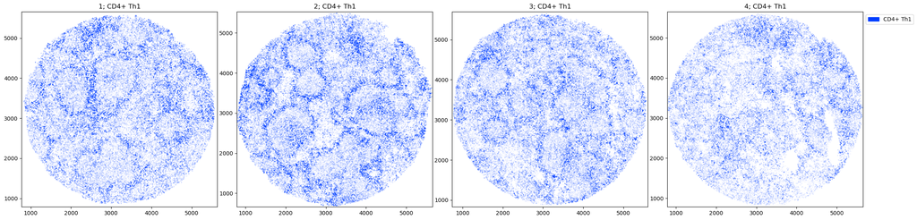

[figure not shown]

```python
puck.obsm['deconv']
puck.obs['CD4+ Th1'] = puck.obsm['deconv']['CD4+ Th1']
puck.obs['x'] = puck.obsm['spatial'][:,0]
puck.obs['y'] = puck.obsm['spatial'][:,1]

tc.pl.scatter(puck, 'CD4+ Th1', group_key='batch')
```

Finally, if you want, you can save the data somewhere. It's in anndata format so you can save it as a .h5ad using `puck.write_h5ad('/data/path/_.h5ad')`. Thanks for following along.